# Black sea bass

Author

cslovas

## What is happening with black sea bass?

[figure not shown]

Pulling together bottom trawl survey data, federal landings, and federal license data, here we explore black sea bass access and exploitation.

#### Helpful information on black sea bass (*Centropristis striata*)

- [Atlantic States Marine Fisheries Commission](https://www.asmfc.org/species/black-sea-bass)
- [NOAA Fisheries](https://www.fisheries.noaa.gov/species/black-sea-bass)

## Distributions

### Average biomass and center of biomass based on NEFSC bottom trawl survey

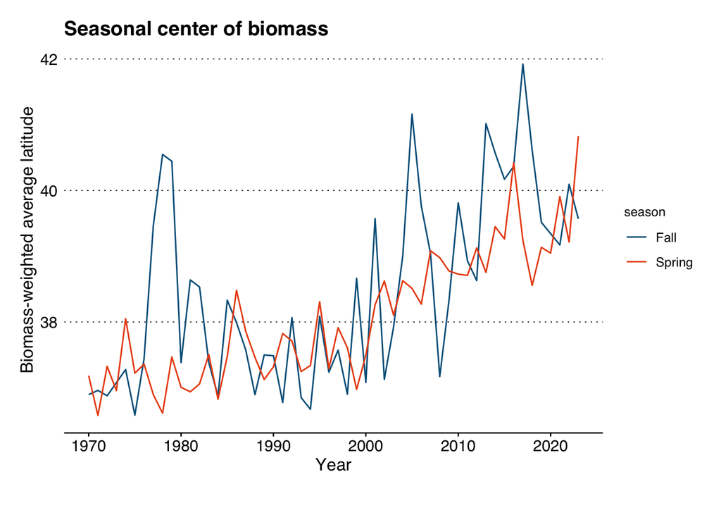

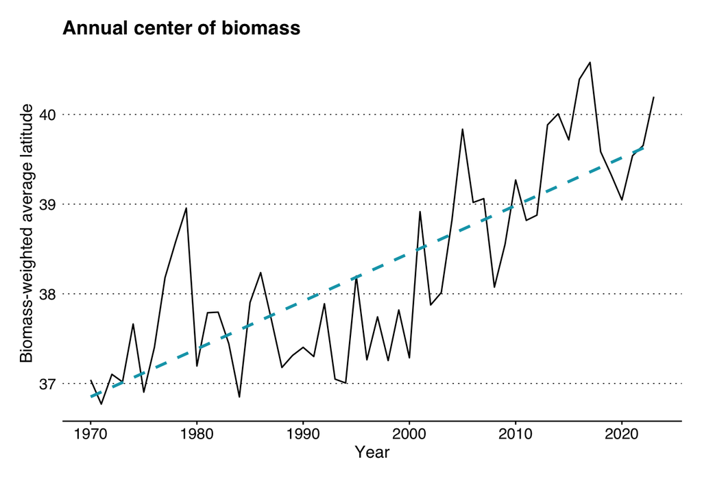

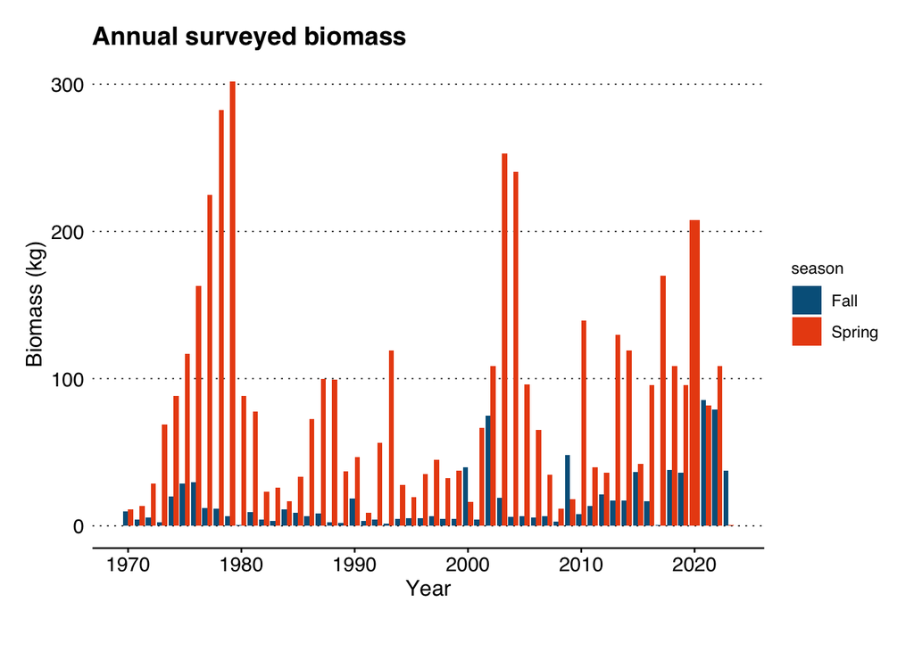

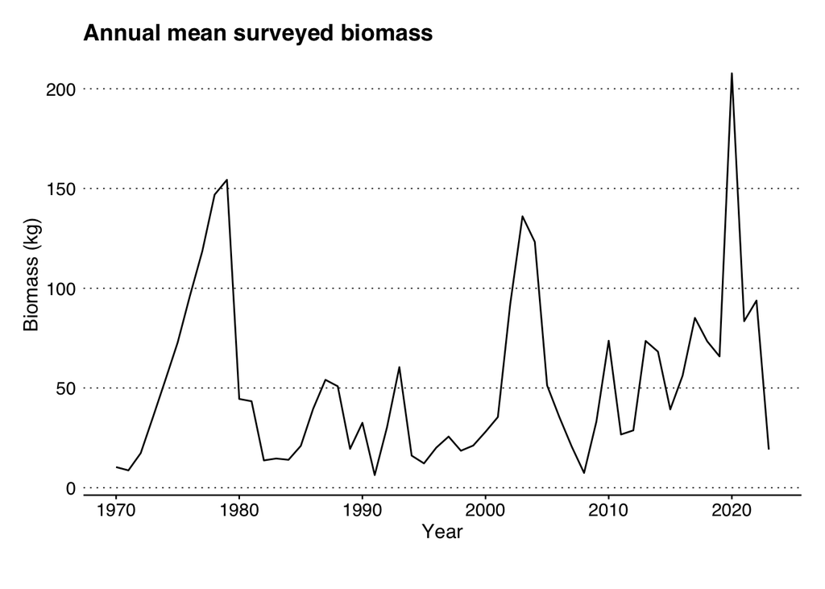

### Leading and trailing edges

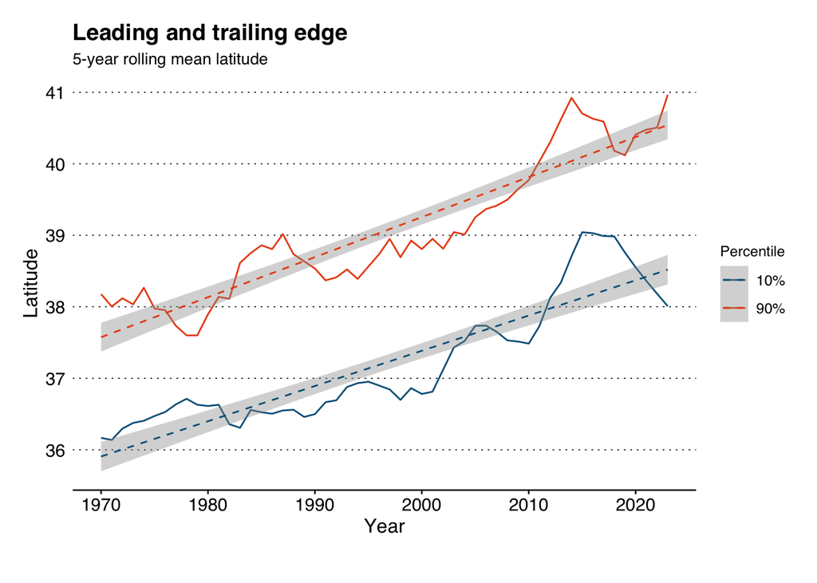

## Landings

### Federally reported landings

Dealer data provided by Greater Atlantic Regional Fisheries Office

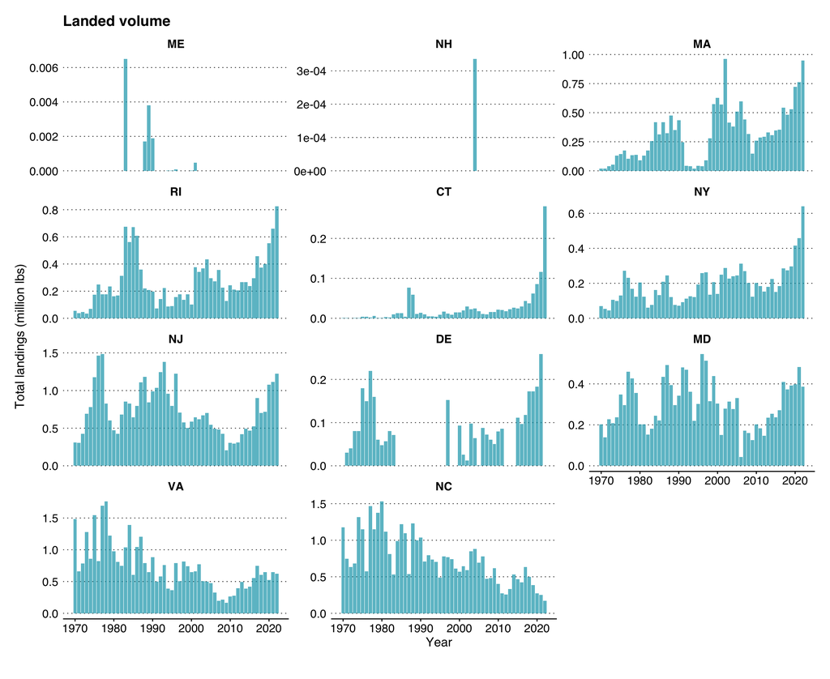

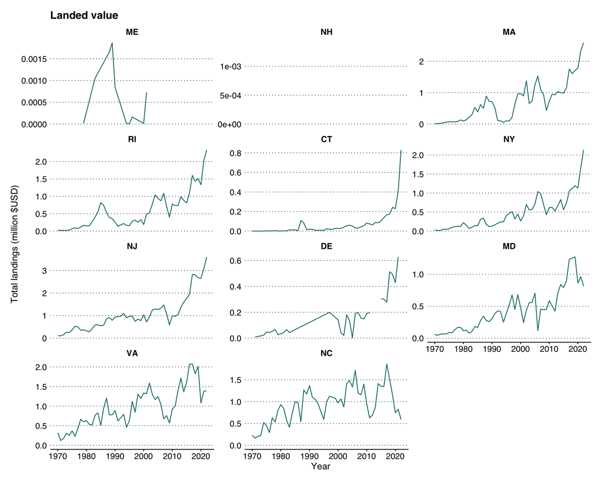

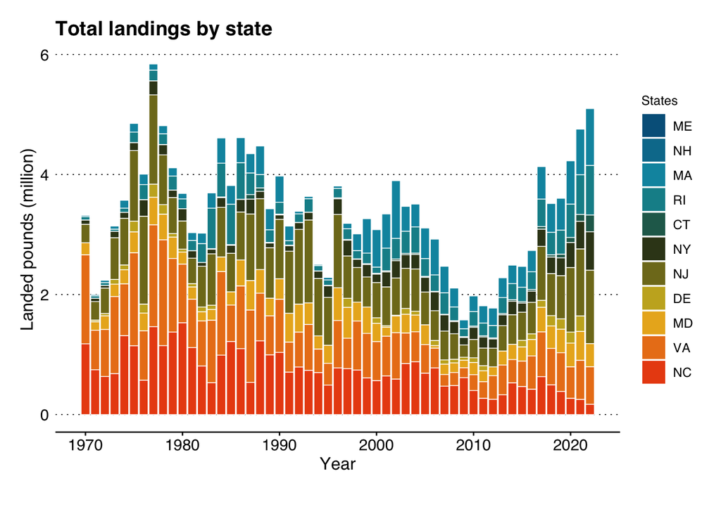

### Ex-vessel price of black sea bass

Despite a general upward trend in landed volume and value, the price per pound has dropped significantly in all regions. Maine is leftout due to lack of data.

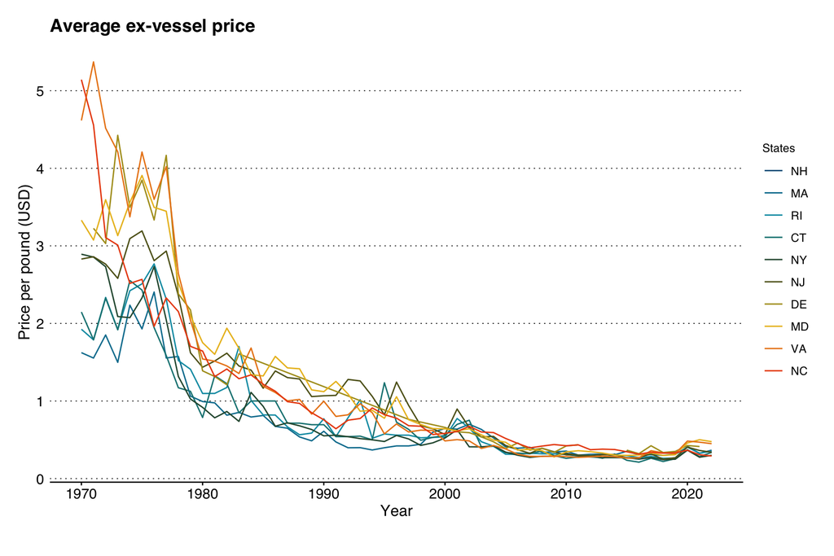

## Licensing

### Federal Licenses

There are two categories of federally issued black sea bass licenses.

- **Category** 1: Commercial (moratorim)
  - *Commercial (moratorium) permits have been managed under a limited entry system since 1996; no new moratorium permits are being issued.*
- **Category 2**: Recreational charter/party

Given our focus on commercial harvest, we will focus only on **Category** 1.

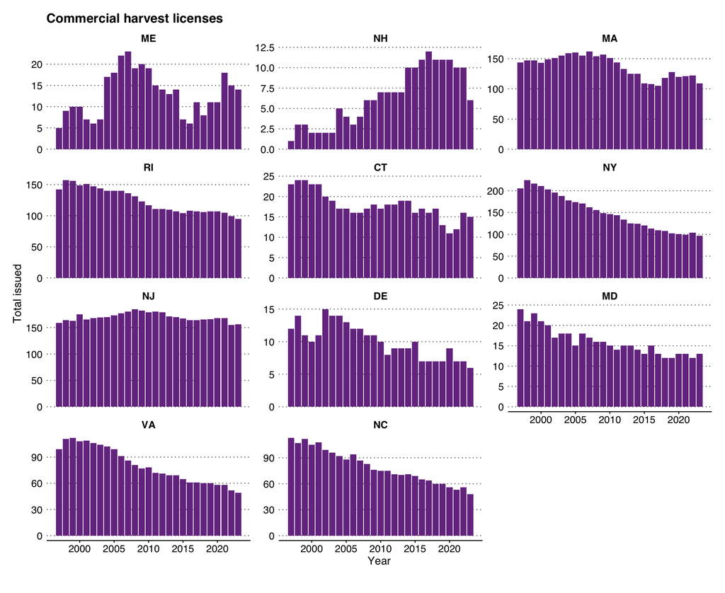

*If Commercial black sea pass permits have been under limited entry since 1996, why are there increases in the number of permits held in some years. Should they all be declining? Are some transferring across state lines*

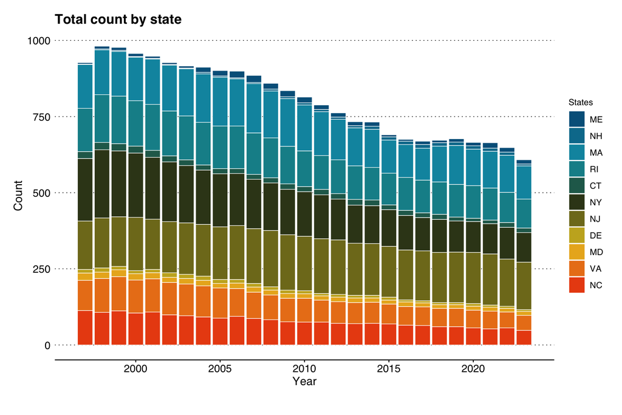

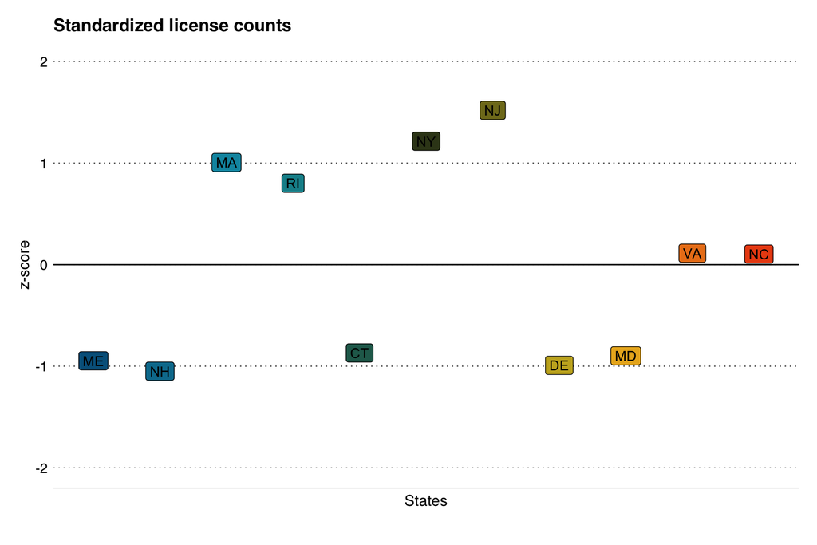

### Vessels & Multiple licenses

Given that licenses are attached to a vessel (and potentially other license types?) and we are reporting location based on principal ports, we cannot definitely say that black sea bass licenses are increasing/decreasing in certain states. We can, however, say that the number of vessels that hold bsb licenses are landing more/less in a particular state. Therefore, we need to explore what other license are co-held with black sea bass and explore the trends with those license types.

*Black sea bass is managed under one FMP with summer flounder and scup*

[interactive chart not shown]

The highest number of co-occurences of black sea bass with another license category is with squid/mackerel/butterfish at 45,736 connections from 1996-2023.

## What do we know so far?

Access into emerging fisheries is a pillar of fisheries climate adaptation. The licensing data shows little evidence of licenses trailing species northwards or transfers across state lines. The overall number of licenses has decreased over time while the relative proportions of which states hold licenses as remained roughly the same.

All the while, landings of black sea bass continue to increase, potentially prompting a drop in ex-vessel price across the northeast.

These pieces together suggest that while black sea bass has the potential to be a viable fishery in New England, quota allocation and limited entry impedes the ability for harvesters to invest in and explore this opportunity. This inaccessability to diversification leaves harvesters susceptible to climate-fisheries change.